# Analyzing the NYC Subway Dataset

Student: Ada Lee  
Date: 2015-10-2

## Section 0. References

[1] http://stackoverflow.com/questions/3541713/how-to-plot-two-histograms-together-in-r  
[2] https://en.wikipedia.org/wiki/Dummy_variable_(statistics)  
[3] http://statsmodels.sourceforge.net/devel/generated/statsmodels.regression.linear_model.OLS.html  
[4] http://pandas.pydata.org/pandas-docs/stable/generated/pandas.get_dummies.html  
[5] http://pandas.pydata.org/pandas-docs/stable/merging.html  
[6] http://blog.minitab.com/blog/adventures-in-statistics/regression-analysis-how-do-i-interpret-r-squared-and-assess-the-goodness-of-fit  
[7] http://docs.ggplot2.org/current/geom_abline.html

## Section 1. Statistical Test

```
average entries with and without rain:2028.19603547, 1845.53943866
```

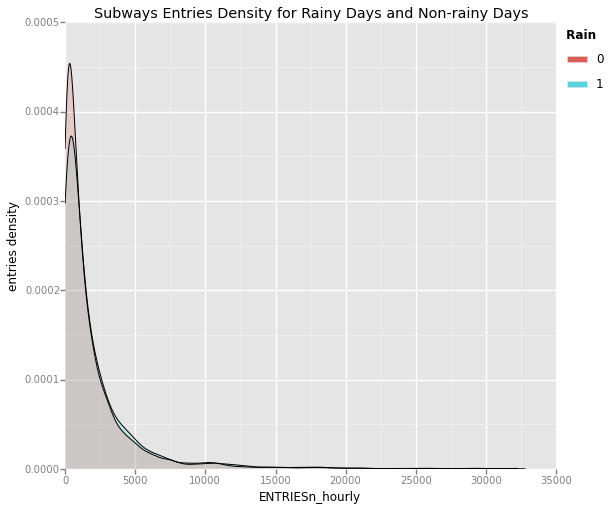

```python
import pandas as pd
import numpy as np
from ggplot import *

turnstile_weather = pd.read_csv('data/turnstile_weather_v2.csv')
entries_with_rain = turnstile_weather['ENTRIESn_hourly'][turnstile_weather['rain'] == 1]
entries_without_rain = turnstile_weather['ENTRIESn_hourly'][turnstile_weather['rain'] == 0]
avg_entries_with_rain = np.mean(entries_with_rain)
avg_entries_without_rain = np.mean(entries_without_rain)
print "average entries with and without rain:{}, {}\n".format(avg_entries_with_rain, avg_entries_without_rain)

%matplotlib inline
ggplot(aes(x='ENTRIESn_hourly', fill='rain'), data=turnstile_weather) + geom_density(alpha = 0.2) + ylab('entries density') + ggtitle('Subways Entries Density for Rainy Days and Non-rainy Days')
```

### Choose statistical test

From the graph we can see that both distribution are right-skewed, so we could not use z-test or t-test. We also don't know distribution of the entries population for rainy days and non-raniy days. The Mann Whitney U test is a non-parametric test that can be used to test, for two populations with unknown distributions. So Mann Whitney U test would be appropriate for our choice. I would prefer to use two-tailed test.

### Hypothesis

Giving random draws x from entries population in rainy days, y from entries population in non-rainy days, we have below null hypothesis and alternative hypothesis

$$H_0: P(x > y) = 0.5$$

$$H_a: P ( x > y ) \neq 0.5$$

### Calculate p value

```python
import scipy.stats
U, one_tailed_p = scipy.stats.mannwhitneyu(entries_with_rain, entries_without_rain)
p = one_tailed_p * 2
print "p value for two-tailed test is", p
print "\nmean entries in rainy days is", avg_entries_with_rain
print "mean entries in non-rainy days is", avg_entries_without_rain
```

```
p value for two-tailed test is 5.48213914249e-06

mean entries in rainy days is 2028.19603547
mean entries in non-rainy days is 1845.53943866
```

### Significance and interpretation

We use two-tailed test and get p value $p=5.48\times 10^{-6},\; p << 0.01$, so we reject the null hypothesis, thus we accept the alternative hypothesis $P ( x > y ) \neq 0.5$, in other words probability of entries in rainy days larger than enties in non-rainy days is not equal to 0.5. This means that rain do affect subway entries.

## Section 2. Linear Regression

I use OLS for linear regression, and try to add information to features as more as possible, so I would add all numeric variables about the weather, they are `precipi`, `pressurei`, `tempi`, `wspdi`, `meanprecipi`, `meanpressurei`, `meantempi`, `meanwspdi`. For dummy variables, `UNIT` and `station` are similar, and I find that only use `UNIT` as feature would result in $R^2$ 0.375, only use `station` as feature would result in $R^2$ 0.324, so I prefer to add `UNIT` as one of the dummy variables. For dummy variables about dates, `datetime`'s information already cover `DATEn`, `TIMEn`, `hour`, `day_week`, `weekday`, so I would only add `datetime` as one of dummy variables. Finally I would add dummy variable `conds`, because adding it increases $R^2$ for my model. For `weather_lat` and `weather_lon`, I don't think it would affect entries, and acturally I also try to add these, but it does not improve $R^2$, so I would not contain it to my final model.

```python
import statsmodels.api as sm

def linear_regression(features, values):
    """
    Perform linear regression given a data set with an arbitrary number of features.
    """
    features = sm.add_constant(features)
    model = sm.OLS(values, features)
    results = model.fit()
    return results

values = turnstile_weather['ENTRIESn_hourly']

features = pd.get_dummies(turnstile_weather['UNIT'], prefix='unit')
print "R square for model that only contain UNIT as feature:", linear_regression(features, values).rsquared
features = pd.get_dummies(turnstile_weather['station'], prefix='station')
print "R square for model that only contain station as feature:", linear_regression(features, values).rsquared
## regression without cond
numerics = ['precipi', 'pressurei','tempi', 'wspdi',
            'meanprecipi', 'meanpressurei', 'meantempi', 'meanwspdi']
dummies = ['fog', 'rain']
features = turnstile_weather[numerics + dummies]
dummy_units = pd.get_dummies(turnstile_weather['UNIT'], prefix='unit')
features = features.join(dummy_units)
dummy_units = pd.get_dummies(turnstile_weather['datetime'])
features = features.join(dummy_units)
print "R square for model that does not contain cond as dummy feature:", linear_regression(features, values).rsquared
## add cond
dummy_units = pd.get_dummies(turnstile_weather['conds'])
features = features.join(dummy_units)
model_results = linear_regression(features, values) # This is my final model, so I would like to keep it
print "R square for model that add cond as dummy feature:", model_results.rsquared
## add weather_lat and weather_lon
features.add(turnstile_weather[['weather_lat', 'weather_lon']])
print "R square for model that add weather_lat and weather_lon:", linear_regression(features, values).rsquared
```

```
R square for model that only contain UNIT as feature: 0.375215669669
R square for model that only contain station as feature: 0.32426305927
R square for model that does not contain cond as dummy feature: 0.574630122144
R square for model that add cond as dummy feature: 0.575449558659
R square for model that add weather_lat and weather_lon: 0.575449558659
```

### Visualzie to see how the model works

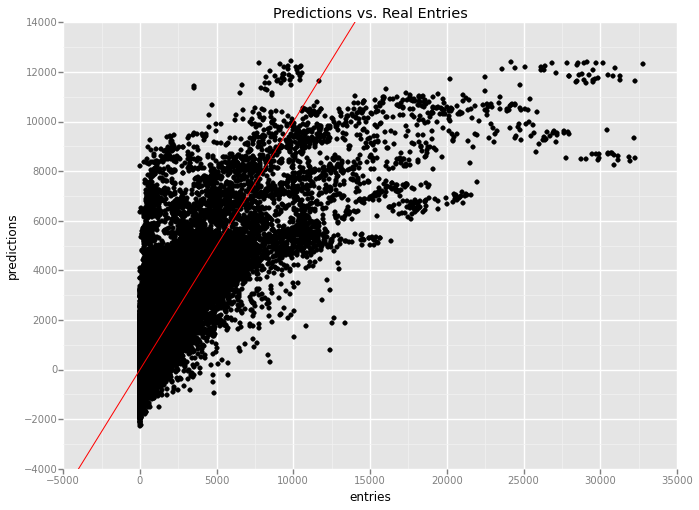

```python
intercept = model_results.params[0]
params = model_results.params[1:]
predictions = intercept + np.dot(features, params)
values_and_predictions = pd.DataFrame({'entries':values, 'predictions':predictions})
ggplot(aes(x='entries', y='predictions'), data=values_and_predictions) + geom_point() + geom_abline(slope=1, intercept=0, color='red') +  ggtitle('Predictions vs. Real Entries')
```

Look like our model is not very good, we will discuss later.

### Parameters of the non-dummy features in the linear regression model and parameter for some dummy variables.

```python
from pprint import pprint

print "parameters for non-dummy features:\n"
pprint(params[numerics])
print "\n\nparameter for some dummy variables:\n"
pprint(params[dummies])
```

```
parameters for non-dummy features:

precipi         -3792.072402
pressurei       -4973.951326
tempi             -29.882949
wspdi             -37.998156
meanprecipi      7366.325239
meanpressurei    7801.363724
meantempi           9.448061
meanwspdi          28.516045
dtype: float64


parameter for some dummy variables:

fog    -902.555592
rain      9.635547
dtype: float64
```

### $R^2$

The definition of R-squared is fairly straight-forward; it is the percentage of the response variable variation that is explained by a linear model.

```python
rsquared = model_results.rsquared
print "rsquared:", rsquared
```

```
rsquared: 0.575449558659
```

$R^2$ is roughly 0.575, that means that 57.5% variance of entries are expalined by our linear model.

### Plot residuals

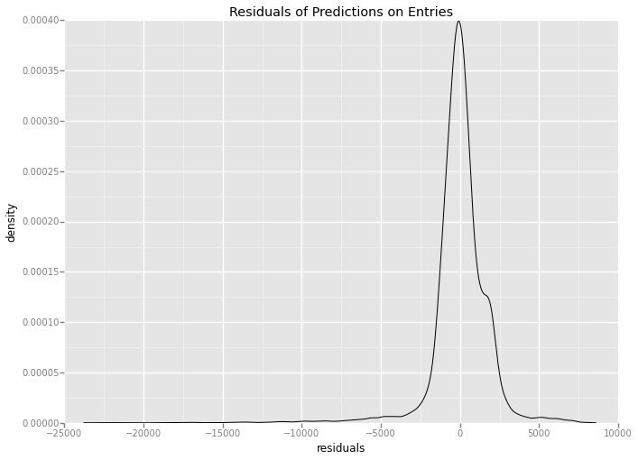

```python
residuals = pd.DataFrame({'residuals': np.array(predictions) - np.array(values)})
ggplot(aes(x='residuals'), data=residuals) + geom_density() + ggtitle('Residuals of Predictions on Entries') + ylab('density')
```

We can see that some residuals are very large, and residuals are not symmetric, this make us to question linearity of features and values. Linear model look like not look very well for this dataset.

## Section 3. Visualization

### ENTRIESn_hourly for rainy days and non-rainy days

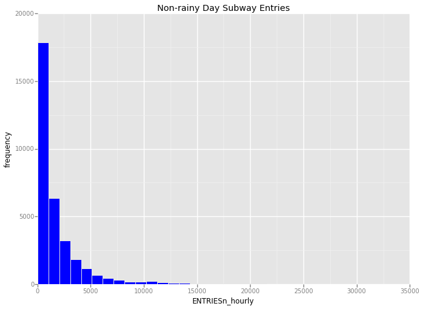

```python
ggplot(aes(x='ENTRIESn_hourly'), data=turnstile_weather[turnstile_weather['rain'] == 0]) + geom_histogram(fill='blue', binwidth=1000) + ylim(0, 20000) + ggtitle('Non-rainy Day Subway Entries') + ylab('frequency')
```

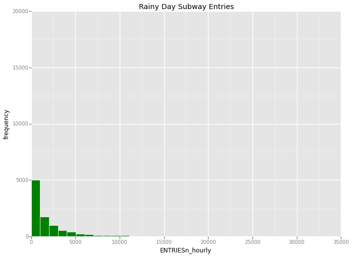

```python
ggplot(aes(x='ENTRIESn_hourly'), data=turnstile_weather[turnstile_weather['rain'] == 1]) + geom_histogram(fill='green', binwidth=1000) + ylim(0, 20000) + ggtitle('Rainy Day Subway Entries') + ylab('frequency')
```

```python
import collections as c
c.Counter(turnstile_weather['rain'])
```

```
Counter({0: 33064, 1: 9585})
```

### Ridership by time-of-day

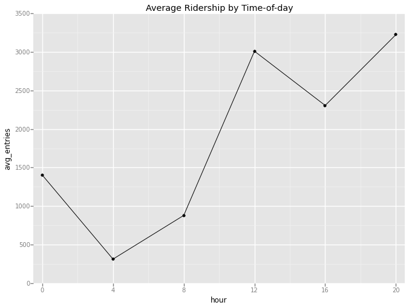

```python
from pandasql import sqldf

q = '''
select hour, avg(ENTRIESn_hourly) as avg_entries
from turnstile_weather
group by hour'''
avg_entries_for_hours = sqldf(q.lower(), locals())

avg_entries_for_hours

ggplot(aes(x='hour', y='avg_entries'), data=avg_entries_for_hours) + geom_line() + geom_point() + xlim(-.5, 20.5) + ggtitle('Average Ridership by Time-of-day') + scale_x_continuous(breaks=range(0, 21, 4))
```

We can see that in hour 20 people take subway most, and in hour 12 people take subway the second most, in hour 4 people take subway least frequent.

## Section 4. Conclusion

```python
params['rain']
```

```
9.6355465616703455
```

From our Mann Whitney U-test, we see that rain do affect subways entries. From our linear model, we can coefficient of rain is 9.64, that means that when it is rainy, more people tend to take subway. In conclusion, rain significantly increase NYC subway entries.

## Section 5. Reflection

```python
unit_vs_date = {key:set() for key in turnstile_weather['UNIT']}
for unit, date in zip(turnstile_weather['UNIT'], turnstile_weather['DATEn']):
    unit_vs_date[unit].add(date)
unit_vs_days = [(unit, len(unit_vs_date[unit])) for unit in sorted(unit_vs_date.keys())]
print 'total units:', len(turnstile_weather['UNIT'])
print '\n units that has less than 31 days date:'
pprint(filter(lambda x: x[1] != 31, unit_vs_days))
print '\ndata count for hours:'
pprint(sorted(c.Counter(turnstile_weather['hour']).items()))
```

```
total units: 42649

 units that has less than 31 days date:
[('R228', 30),
 ('R253', 29),
 ('R260', 28),
 ('R273', 30),
 ('R295', 29),
 ('R356', 30),
 ('R453', 30),
 ('R459', 16)]

data count for hours:
[(0.0, 7378),
 (4.0, 7381),
 (8.0, 5914),
 (12.0, 7335),
 (16.0, 7298),
 (20.0, 7343)]
```

```python
unit_vs_date['R459']
```

```
{'05-14-11',
 '05-15-11',
 '05-16-11',
 '05-17-11',
 '05-18-11',
 '05-19-11',
 '05-20-11',
 '05-23-11',
 '05-24-11',
 '05-25-11',
 '05-26-11',
 '05-27-11',
 '05-28-11',
 '05-29-11',
 '05-30-11',
 '05-31-11'}
```